# cpCaller - Vignette

Ferran Nadeu

nadeu@recerca.clinic.cat

2026-03-23

# 1 Introduction

# 2 Prepare input files

Before running cpCaller, we have to define the required input files, paths, and arguments as follows:

## 2.1 Bed file

Bed-like file containing 4 columns: chrom, start, end, gene_name. This file should not contain colum names. It should be tab-separated.

```r
bedFile <- "inputs/target_regions.bed"
bf <- read.table(bedFile, sep = "\t", header = F, stringsAsFactors = F)
head(bf)
```

```
##   V1        V2        V3     V4
## 1  1 119915291 119916709 NOTCH2
## 2  1 119922621 119922793 NOTCH2
## 3  1 119923622 119923999 NOTCH2
## 4  2 230225830 230225918  SP140
## 5  2 230237068 230237275  SP140
## 6  2 230238198 230238396  SP140
```

## 2.2 List of bam files

Prepare list of paths to the tumor and normal BAM files:

```r
bamFilesTumors <- list.files(path = "bams/tumor", pattern = "*.bam$", full.names = T)
print(bamFilesTumors)
```

```
## [1] "bams/tumor/M004.bam" "bams/tumor/M019.bam" "bams/tumor/M031.bam"
## [4] "bams/tumor/M162.bam" "bams/tumor/M441.bam"
```

```r
bamFilesNormals <- list.files(path = "bams/normal", pattern = "*.bam$", full.names = T)
print(bamFilesNormals)
```

```
## [1] "bams/normal/normalFFv1-1.bam" "bams/normal/normalFFv1-2.bam"
## [3] "bams/normal/normalFFv1-3.bam" "bams/normal/normalFFv1-4.bam"
## [5] "bams/normal/normalFFv1-5.bam" "bams/normal/normalFFv1-6.bam"
## [7] "bams/normal/normalFFv1-7.bam" "bams/normal/normalFFv1-8.bam"
```

## 2.3 List of genes

Prepare a list of genes to be analyzed (must be included in the bed-like file):

```r
lstGenes <- c("NOTCH2","SP140","NSD2","MYC","CDKN2A","CDKN2B","NOTCH1","CCND1","TP53")
```

## 2.4 Normalization

Define the normalization method to be used (by default it uses “median_gene”):

```r
normalization <- "median_gene"
```

## 2.5 Purity

(Optional) Provide the path to a tab-separated file containing the purity of each sample. This file must contain at least two columns (Sample, Purity). ‘Sample’ names must match does used in the BAM files provided.

```r
purity <- "inputs/purity.txt"
pf <- read.table(purity, sep = "\t", header = T, stringsAsFactors = F)
head(pf)
```

```
##   Sample Purity
## 1   M004  1.000
## 2   M019  0.999
## 3   M031  0.979
## 4   M162  0.887
## 5   M441  0.726
```

# 3 Run cpCaller

First, we need to install and load cpCaller:

```r
# library(devtools)
# devtools::install_github("https://github.com/nadeulab/cpCaller/tree/main", build_vignettes = T, dependencies = T)
library("cpCaller")
```

cpCaller is composed of two steps, each of them executed with a specific function. First, we need to run ‘cpCall’ to run the analysis. Second, we can run ‘cpPlot’ to plot the copy number profiles obtained.

## 3.1 Run cpCall

```r
ccObj <- cpCall(bedFile, bamFilesTumors, bamFilesNormals, normalization, lstGenes, purity)
```

```
## cpCall: starting...
```

```
## 1. Processing bed file...
```

```
## 2. Calculating coverage...
```

```
## ...starting with tumor bam files...
```

```
## ...starting with normal bam files...
```

```
## 3. Normalizing coverage of the samples...
```

```
## 4. Normalizing coverage of each window...
```

```
## 5. Step skipped because running in smooth = FALSE...
```

```
## 6. Estimating noise and calling gene-level copy numbers...
```

```
## 7. Ploting QC plots...
```

```
## 8. Preparing output object...
```

```
## Done!
```

## 3.2 Run cpPlot

```r
ccPlo <- cpPlot(ccObj, "simple", purity)
```

```
## cpPlot: starting...
```

```
## ... plotType = simple...
```

```
## 1. Preparing inputs and tables...
```

```
## 2. Ploting...
```

```
## Done!
```

# 4 Outputs of cpCaller

Once we have run these two functions, we can explore the outputs:

## 4.1 QC plots

This plot shows the standard deviation of the mean coverages of the target regions of each gene:

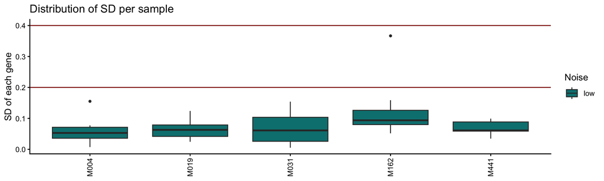

```r
ccObj$plot_SD_samples
```

This plot shows the distribution of mean standard deviation of the samples. The red verticle lines define the cutoffs to classify samples as low, intermediate, and high “noise”.

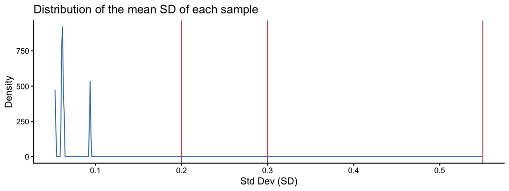

```r
ccObj$plot_SD_distribution
```

This plot shows the distribution of the normalized coverage per sample:

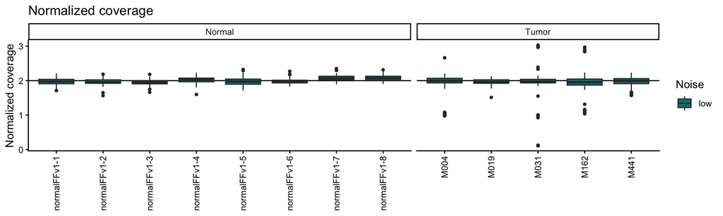

```r
ccObj$plot_Normalized_coverage
```

## 4.2 Copy number calls

The copy number calls are stored in ‘table_CNcalls’:

```r
CN <- ccObj$table_CNcalls
DT::datatable(CN, options = list(scrollX = T, scrollY=T), rownames = F)
```

| Sample | Gene | minObs | q20Obs | meanObs | medianObs | q80Obs | maxObs | sdObs | minBack | q20Back | meanBack | medianBack | q80Back | maxBack | sdBack | log2Min | log2q20 | log2Mean | log2Median | log2q80 | log2Max | Noise | Call | TotalCN |
| --- | --- | --- | --- | --- | --- | --- | --- | --- | --- | --- | --- | --- | --- | --- | --- | --- | --- | --- | --- | --- | --- | --- | --- | --- |
| M004 | NOTCH2 | 1.98926458930658 | 1.99377360490653 | 1.99763715020479 | 2.00053712830647 | 2.00208069112339 | 2.00310973300133 | 0.00736406176812557 | 1.83431064561851 | 1.97452563382114 | 2 | 1.99096952487982 | 2.04724652749151 | 2.08908615466735 | 0.0540761333539108 | 0.116997195739588 | 0.0139955021207962 | -0.00170544346612498 | 0.00691626578725246 | -0.0321847195995574 | -0.0606305348378021 | low | wt | 2 |
| M004 | SP140 | 1.76182173113815 | 1.93496009788877 | 2.01653497885989 | 1.99255374204336 | 2.07268236778076 | 2.66354283417518 | 0.155131241641616 | 1.56498282635638 | 1.89405218507224 | 2 | 1.99343050064276 | 2.1050111440365 | 2.34528936180351 | 0.131646059191097 | 0.170921127871723 | 0.0308277352942319 | 0.0118784309806 | -0.000634671502337477 | -0.0223288262195085 | 0.183580548570822 | low | wt | 2 |
| M004 | NSD2 | 1.99644756151678 | 2.01142914542403 | 2.0339015212849 | 2.0339015212849 | 2.05637389714578 | 2.07135548105303 | 0.0529678978686633 | 1.90364214377753 | 1.95953175599614 | 2 | 1.99023531598369 | 2.05086007670894 | 2.11472518281982 | 0.0612631365449601 | 0.068672879725608 | 0.037711965186357 | 0.0242498275762494 | 0.031310809303747 | 0.00387353933569477 | -0.0298950247451049 | low | wt | 2 |
| M004 | MYC | 2.07084532460661 | 2.09664308980889 | 2.12162141339621 | 2.12469508058701 | 2.15334530619324 | 2.15705666391524 | 0.0358295687382154 | 1.80375382316684 | 1.94352017278726 | 2 | 2.00277761784614 | 2.05782033740537 | 2.16474464339444 | 0.0828052143068902 | 0.199217347333516 | 0.10940921107322 | 0.0851672416701435 | 0.085253574232826 | 0.0654626557574466 | -0.00513277718236024 | low | wt | 2 |
| M004 | CDKN2A | 1.97427937100175 | 2.00022680146837 | 2.02603649075104 | 2.031937829385 | 2.0542067154873 | 2.06599093323243 | 0.0398340838848198 | 1.81639989857907 | 1.92833720836143 | 2 | 2.00840495235609 | 2.08381752105737 | 2.13897303930253 | 0.0832898309668909 | 0.120244291919266 | 0.0528062356652128 | 0.0186601586165806 | 0.0168060735191899 | -0.0206475791753419 | -0.050084375326449 | low | wt | 2 |
| M004 | CDKN2B | 1.89856469985857 | 1.93506041630644 | 1.98435918380195 | 1.95713361095654 | 2.06196797404479 | 2.0962947906888 | 0.0774266720494331 | 1.81888984103846 | 1.9230181480278 | 2 | 1.99712582498814 | 2.07183867033738 | 2.17777085793533 | 0.0837687796078183 | 0.0618509939130078 | 0.00900623295127749 | -0.0113268120833584 | -0.0291829795776141 | -0.00688974249686035 | -0.0550105540411122 | low | wt | 2 |
| M004 | NOTCH1 | 2.04347780876047 | 2.05835904628778 | 2.10515311649067 | 2.0857861468272 | 2.14420039882817 | 2.20556236354781 | 0.0712950649796026 | 1.85614749059444 | 1.95663547245316 | 2 | 2.00312025788168 | 2.05308458043455 | 2.18097150567452 | 0.063710871160296 | 0.138715223996946 | 0.0731196559639245 | 0.073925170283629 | 0.0583422112849026 | 0.0626466845928151 | 0.0161756327056083 | low | wt | 2 |
| M004 | CCND1 | 1.93982413136154 | 1.98741897465813 | 2.03501717779876 | 2.04103024168581 | 2.08131005892014 | 2.18709403523859 | 0.0661945474683908 | 1.82832057863048 | 1.93963464644534 | 2 | 1.99314068411772 | 2.06848940828731 | 2.2068439426519 | 0.0726076404757656 | 0.0854068050633545 | 0.0351111151647132 | 0.0250409724868458 | 0.0342540136008588 | 0.00891433337110414 | -0.012969361658597 | low | wt | 2 |
| M004 | TP53 | 0.976698433296835 | 0.99594331494588 | 1.02973539001342 | 1.03180208585887 | 1.06120334254173 | 1.08209612003778 | 0.0344658786663279 | 1.71552161549562 | 1.89949124861434 | 2 | 2.0014612757725 | 2.09493788424442 | 2.21818064696775 | 0.112300831579484 | -0.812662216275839 | -0.931477527803756 | -0.957726342747183 | -0.955887434651045 | -0.981206343229766 | -1.03554820624251 | low | del | 1.03180208585887 |
| M019 | NOTCH2 | 1.91013979397472 | 1.95085382983711 | 1.98234158382944 | 2.01192488363069 | 2.01974599778203 | 2.02496007388292 | 0.0628673435886783 | 1.83431064561851 | 1.97452563382114 | 2 | 1.99096952487982 | 2.04724652749151 | 2.08908615466735 | 0.0540761333539108 | 0.0584402420103102 | -0.0174004111074399 | -0.0127944205047442 | 0.0151053039365614 | -0.0195109689970917 | -0.0449785282220065 | low | wt | 2 |

[output cut: 35 more lines]

## 4.3 Copy number profiles

The plot the copy number profiles of each sample:

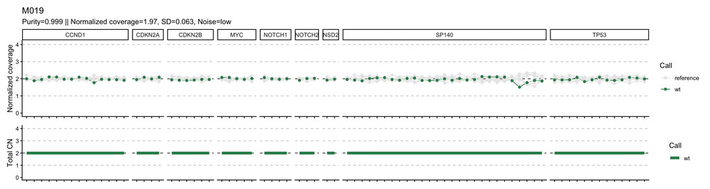

```r
ccPlo$M019
```

This is the standard plot of cpCaller. In the title it shows the sample name, the purity provided (and used during the analysis), the mean normalized coverage of the sample, the standard deviation of the coverage, and the noise category (low, intermediate, high). This noise category is used to define cutoffs to call CNA.

The plot on the top shows the distribution of the normalized coverage of each target region, grouped by gene. The reference samples (i.e., non-tumoral/normal) are shown in grey.

The plot on the bottom shows the copy number state of each gene, which is corrected by purity (if available).

If a sample has a copy number deletion, it will look as follows:

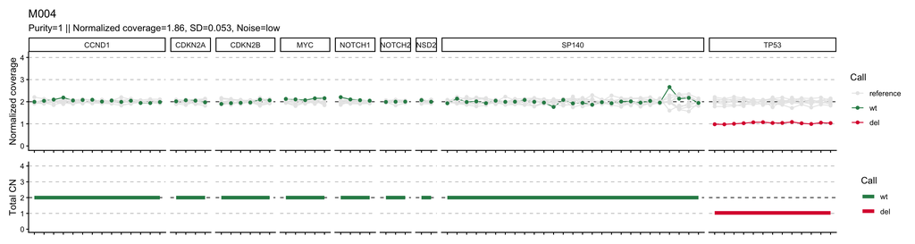

```r
ccPlo$M004
```

Below there is an example of sample carrying homozigous and heterozygous deletions as well as a gain:

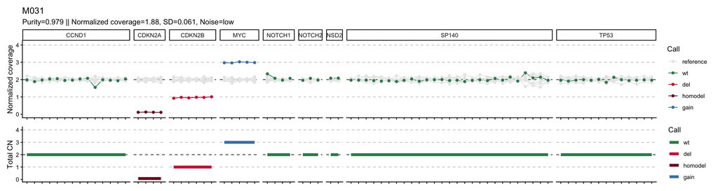

```r
ccPlo$M031
```

Here an example of a sample in which the tumor cell content (i.e., purity) was relatively low, to illustrate how the total CN is adjusted considering the purity provided:

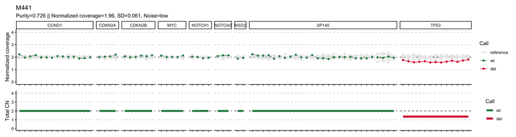

```r
ccPlo$M441
```

And, finally, an example in which only a fraction of a gene is deleted:

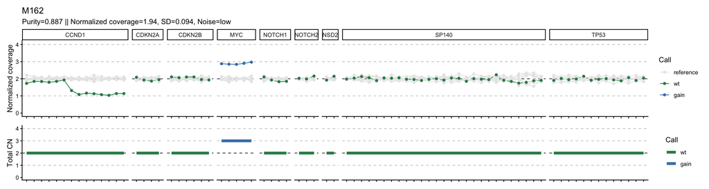

```r
ccPlo$M162
```

## 4.4 Other outputs of cpCall

Other outputs of the cpCall function include the raw and normalized counts, and sample metrics:

```r
names(ccObj)
```

```
##  [1] "plot_SD_distribution"          "plot_Normalized_coverage"
##  [3] "plot_SD_samples"               "table_rawCountsNormal"
##  [5] "table_rawCountsTumor"          "table_normalizedCountsNormal"
##  [7] "table_normalizedCountsTumor"   "table_tumorAndSelectedNormals"
##  [9] "table_sampleMetrics"           "table_CNcalls"
```